# Pandas

`imports`, you've seen this before!

```python
pip install matplotlib numpy pandas openpyxl
```

```python
import matplotlib
import matplotlib.pyplot as plt
import numpy as np
import pandas as pd
import os
from datetime import datetime
```

```python
pip install jupyter jupyter-server notebook RISE
```

[output not shown]

[output not shown]

Some magic that tells jupyter to put graphs and things in the notebook instead of the default behaviour which is to save it as a file.

```python
%matplotlib inline
```

Set the size of the plots that will come out when we ask for them. Annoyingly, these are in inches. Whatever an "inch" is

```python
plt.rcParams['figure.figsize'] = (10, 5)
```

```python
saved_style_state = matplotlib.rcParams.copy() #give us a style state to go back to
```

```python
pip install RISE
```

# Data Project

Analysing the Shark Research Institute's dataset. The goal of this dataset is to inform people about the risks associated with coastal water activities, and to improve shark/human relations by educating people in factors that contribute to shark attacks.

```python
filepath = "GSAF5.xls.xlsx"

sad = pd.read_excel(filepath)
print("done")
```

```
done
```

SAD meaning Shark Attack Data

# 1. SHOW DATA SET

```python
sad.head()
```

|  | Case Number | Date | Year | Type | Country | Area | Location | Activity | Name | Gender | ... | Species | Investigator or Source | pdf | href formula | href | Case Number.1 | Case Number.2 | original order | Unnamed: 22 | Unnamed: 23 |
| --- | --- | --- | --- | --- | --- | --- | --- | --- | --- | --- | --- | --- | --- | --- | --- | --- | --- | --- | --- | --- | --- |
| 0 | 2020.02.05 | 05-Feb-2020 | 2020.0 | Unprovoked | USA | Maui | NaN | Stand-Up Paddle boarding | NaN | NaN | ... | Tiger shark | K. McMurray, TrackingSharks.com | NaN | NaN | NaN | NaN | NaN | NaN | NaN | NaN |
| 1 | 2020.01.30.R | 30-Jan-2020 | 2020.0 | Provoked | BAHAMAS | Exumas | NaN | Floating | Ana Bruna Avila | F | ... | NaN | K. McMurray, TrackingSharks.com | NaN | NaN | NaN | NaN | NaN | NaN | NaN | NaN |
| 2 | 2020.01.17 | 17-Jan-2020 | 2020.0 | Unprovoked | AUSTRALIA | New South Wales | Windang Beach | Surfing | Will Schroeter | M | ... | "A small shark" | B. Myatt & M. Michaelson, GSAF; K. McMurray, T... | 2020.01.17-Schroeter.pdf | http://sharkattackfile.net/spreadsheets/pdf_di... | http://sharkattackfile.net/spreadsheets/pdf_di... | 2020.01.17 | 2020.01.17 | 6502.0 | NaN | NaN |
| 3 | 2020.01.16 | 16-Jan-2020 | 2020.0 | Unprovoked | NEW ZEALAND | Southland | Oreti Beach | Surfing | Jordan King | F | ... | Broadnose seven gill shark? | K. McMurray, TrackingSharks.com | 2020.01.16-King.pdf | http://sharkattackfile.net/spreadsheets/pdf_di... | http://sharkattackfile.net/spreadsheets/pdf_di... | 2020.01.16 | 2020.01.16 | 6501.0 | NaN | NaN |
| 4 | 2020.01.13 | 13-Jan-2020 | 2020.0 | Unprovoked | USA | North Carolina | Rodanthe, Dare County | Surfing | Samuel Horne | M | ... | NaN | C. Creswell, GSAF | 2020.01.13-Horne.pdf | http://sharkattackfile.net/spreadsheets/pdf_di... | http://sharkattackfile.net/spreadsheets/pdf_di... | 2020.01.13 | 2020.01.13 | 6500.0 | NaN | NaN |

5 rows × 24 columns

```python
for index, row in sad.iterrows():
    print(index,row['Country'])
```

[output not shown]

[output cut: 6446 more lines]

```python
sad.loc[sad['Activity'] == "Swimming"]
```

|  | Case Number | Date | Year | Type | Country | Area | Location | Activity | Name | Gender | ... | Species | Investigator or Source | pdf | href formula | href | Case Number.1 | Case Number.2 | original order | Unnamed: 22 | Unnamed: 23 |
| --- | --- | --- | --- | --- | --- | --- | --- | --- | --- | --- | --- | --- | --- | --- | --- | --- | --- | --- | --- | --- | --- |
| 5 | 2020.01.12 | 12-Jan-2020 | 2020.0 | Unprovoked | THAILAND | Phang Nga Province | Nang Thong Beach | Swimming | Hans-Peter Malten | M | ... | NaN | K. McMurray, TrackingSharks.com | 2020.01.12-Malten.pdf | http://sharkattackfile.net/spreadsheets/pdf_di... | http://sharkattackfile.net/spreadsheets/pdf_di... | 2020.01.12 | 2020.01.12 | 6499.0 | NaN | NaN |
| 6 | 2020.01.07 | 07-Jan-2020 | 2020.0 | Unprovoked | AUSTRALIA | Queensland | North West Island | Swimming | Miah Holmes | F | ... | Lemon shark | B. Myatt & M. Michaelson, GSAF; K. McMurray, T... | 2020.01.07-Holmes.pdf | http://sharkattackfile.net/spreadsheets/pdf_di... | http://sharkattackfile.net/spreadsheets/pdf_di... | 2020.01.07 | 2020.01.07 | 6498.0 | NaN | NaN |
| 10 | 2019.12.30 | 30-Dec-2019 | 2019.0 | Unprovoked | AUSTRALIA | Queensland | North West Island | Swimming | male | M | ... | Shovelnose "shark" which is a ray, not a shark) | B. Myatt, GSAF | 2019.12.30-Queensland.pdf | http://sharkattackfile.net/spreadsheets/pdf_di... | http://sharkattackfile.net/spreadsheets/pdf_di... | 2019.12.30 | 2019.12.30 | 6494.0 | NaN | NaN |
| 11 | 2019.12.28 | 28-Dec-2019 | 2019.0 | Unprovoked | SEYCHELLES | Praslin | Amitié Beach | Swimming | female | F | ... | NaN | Seychelles News Agency | 2019.12.28-Seychelles.pdf | http://sharkattackfile.net/spreadsheets/pdf_di... | http://sharkattackfile.net/spreadsheets/pdf_di... | 2019.12.28 | 2019.12.28 | 6493.0 | NaN | NaN |
| 40 | 2019.09.24.b | 24-Sep-2019 | 2019.0 | Unprovoked | USA | Florida | Huguenot Park, Jacksonville, Duval County | Swimming | male | NaN | ... | NaN | Florida Times Union, 9/24/2019 | NaN | NaN | NaN | NaN | NaN | NaN | NaN | NaN |
| ... | ... | ... | ... | ... | ... | ... | ... | ... | ... | ... | ... | ... | ... | ... | ... | ... | ... | ... | ... | ... | ... |
| 6447 | ND.0014 | Before 17-Jul-1916 | 0.0 | Unprovoked | USA | North Carolina | Somewhere between Hatteras and Beaufort | Swimming | "youthful male" | NaN | ... | NaN | C. Creswell, GSAF; Wilmington Star, 7/17/1916 | NaN | NaN | NaN | NaN | NaN | NaN | NaN | NaN |
| 6450 | ND.0011 | Before 1911 | 0.0 | Unprovoked | ASIA? | NaN | NaN | Swimming | Mr. Masury | NaN | ... | NaN | Ref. J. T. Dubois in N.Y. Sun, 3/19/1911 | NaN | NaN | NaN | NaN | NaN | NaN | NaN | NaN |
| 6455 | ND.0006 | Before 1906 | 0.0 | Unprovoked | AUSTRALIA | New South Wales | NaN | Swimming | Arab boy | NaN | ... | Said to involve a grey nurse shark that leapt ... | L. Becke in New York Sun, 9/9/1906; L. Schultz... | NaN | NaN | NaN | NaN | NaN | NaN | NaN | NaN |
| 6458 | ND.0003 | 1900-1905 | 0.0 | Unprovoked | USA | North Carolina | Ocracoke Inlet | Swimming | Coast Guard personnel | NaN | ... | NaN | F. Schwartz, p.23; C. Creswell, GSAF | NaN | NaN | NaN | NaN | NaN | NaN | NaN | NaN |
| 6460 | ND.0001 | 1845-1853 | 0.0 | Unprovoked | CEYLON (SRI LANKA) | Eastern Province | Below the English fort, Trincomalee | Swimming | male | NaN | ... | NaN | S.W. Baker | NaN | NaN | NaN | NaN | NaN | NaN | NaN | NaN |

932 rows × 24 columns

```python
# This allows you to sort data quickly, sorting by Country first then area. Then making country in ascending alphabet order and Area decending
sad.sort_values(['Country', 'Area'], ascending=[1,0])
```

|  | Case Number | Date | Year | Type | Country | Area | Location | Activity | Name | Gender | ... | Species | Investigator or Source | pdf | href formula | href | Case Number.1 | Case Number.2 | original order | Unnamed: 22 | Unnamed: 23 |
| --- | --- | --- | --- | --- | --- | --- | --- | --- | --- | --- | --- | --- | --- | --- | --- | --- | --- | --- | --- | --- | --- |
| 3941 | 1962.10.15 | 15-Oct-1962 | 1962.0 | Unprovoked | ADMIRALTY ISLANDS | Manus Island | Sisi (west coast of island) | NaN | Pasingan | NaN | ... | NaN | SAF Case #1116 | 1742.12.17-AdviceSeamen.pdf | http://sharkattackfile.net/spreadsheets/pdf_di... | http://sharkattackfile.net/spreadsheets/pdf_di... | 1742.12.17 | 1742.12.17 | 148.0 | NaN | NaN |
| 6208 | 1846.09.30.R | Reported 30-Sep-1846 | 1846.0 | Unprovoked | AFRICA | NaN | NaN | Jumped into river | male | NaN | ... | NaN | Hartford Courant, 9/30/1846 | NaN | NaN | NaN | NaN | NaN | NaN | NaN | NaN |
| 6217 | 1844.07.16.R | 1844.07.16.R | 1844.0 | Unprovoked | ALGERIA | NaN | Cape Matifou | Swimming | male | NaN | ... | NaN | C. Moore, GSAF | NaN | NaN | NaN | NaN | NaN | NaN | NaN | NaN |
| 4285 | 1958.12.12 | 1958-12-12 00:00:00 | 1958.0 | Unprovoked | AMERICAN SAMOA | Tutuila Island | Van Camp wharf | Cleaning hull of ship | Sailor of tuna vessel No.12 Taiyo Marei | NaN | ... | Tiger shark | M. Hosina | NaN | NaN | NaN | NaN | NaN | NaN | NaN | NaN |
| 4440 | 1955.08.08 | 1955-08-08 00:00:00 | 1955.0 | Unprovoked | AMERICAN SAMOA | Tutuila Island | Pago Pago Bay | Swimming | Sailor from tuna vessel | NaN | ... | Blue shark | M. Hosina | NaN | NaN | NaN | NaN | NaN | NaN | NaN | NaN |
| ... | ... | ... | ... | ... | ... | ... | ... | ... | ... | ... | ... | ... | ... | ... | ... | ... | ... | ... | ... | ... | ... |
| 6324 | 1638.00.00.R | Reported 1638 | 1638.0 | Unprovoked | NaN | NaN | NaN | NaN | sailors | NaN | ... | NaN | Sir Thomas Herbert | NaN | NaN | NaN | NaN | NaN | NaN | NaN | NaN |
| 6330 | 1555.00.00 | 1555 | 1555.0 | Unprovoked | NaN | NaN | NaN | Swimming | male | NaN | ... | NaN | Olaus Magnus | NaN | NaN | NaN | NaN | NaN | NaN | NaN | NaN |
| 6358 | ND-0124 | Before 2011 | 0.0 | Provoked | NaN | NaN | NaN | NaN | Phillip Peters | NaN | ... | NaN | Watertown Daily Times, 7/8/2011 | NaN | NaN | NaN | NaN | NaN | NaN | NaN | NaN |
| 6365 | ND-0114 | Before 2012 | 0.0 | Unprovoked | NaN | NaN | In a river feeding into the Bay of Bengal | Netting shrimp | Sametra Mestri | NaN | ... | NaN | National Georgraphic Television | NaN | NaN | NaN | NaN | NaN | NaN | NaN | NaN |
| 6418 | ND.0044 | 1941-1945 | 0.0 | Sea Disaster | NaN | NaN | NaN | A group of survivors on a raft for 17-days | C. | NaN | ... | 1.2 m [4'] shark | G.A. Llano in Airmen Against the Sea, p.69 | NaN | NaN | NaN | NaN | NaN | NaN | NaN | NaN |

6461 rows × 24 columns

```python
#sad.Species.value_counts().plot(kind="bar")
```

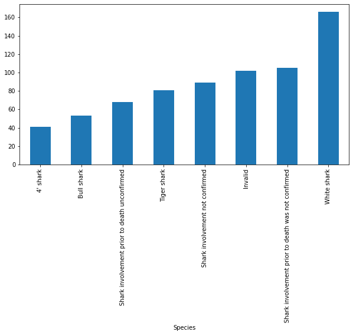

```python
species_count = sad.groupby("Species").count().Date.sort_values()
species_count[species_count > 40].plot(kind="bar")
```

# Making change to data

```python
#sad['']
```

# Filtering Data

```python
# & means and while | means or
sad.loc[(sad['Country'] == 'AUSTRALIA') & (sad['Area'] == 'New South Wales')]
```

|  | Case Number | Date | Year | Type | Country | Area | Location | Activity | Name | Gender | ... | Species | Investigator or Source | pdf | href formula | href | Case Number.1 | Case Number.2 | original order | Unnamed: 22 | Unnamed: 23 |
| --- | --- | --- | --- | --- | --- | --- | --- | --- | --- | --- | --- | --- | --- | --- | --- | --- | --- | --- | --- | --- | --- |
| 2 | 2020.01.17 | 17-Jan-2020 | 2020.0 | Unprovoked | AUSTRALIA | New South Wales | Windang Beach | Surfing | Will Schroeter | M | ... | "A small shark" | B. Myatt & M. Michaelson, GSAF; K. McMurray, T... | 2020.01.17-Schroeter.pdf | http://sharkattackfile.net/spreadsheets/pdf_di... | http://sharkattackfile.net/spreadsheets/pdf_di... | 2020.01.17 | 2020.01.17 | 6502.0 | NaN | NaN |
| 16 | 2019.12.20 | 20-Dec-2019 | 2019.0 | Provoked | AUSTRALIA | New South Wales | Shellharbour | Fishing | NaN | NaN | ... | White shark | B. Myatt, GSAF | 2019.12.20-Shellharbour.pdf | http://sharkattackfile.net/spreadsheets/pdf_di... | http://sharkattackfile.net/spreadsheets/pdf_di... | 2019.12.20 | 2019.12.20 | 6488.0 | NaN | NaN |
| 35 | 2019.10.05.b | 05-Oct-2019 | 2019.0 | Unprovoked | AUSTRALIA | New South Wales | Lighthouse Beach | Surfing | Mike Bruton | NaN | ... | White shark, 3.5 m | B.Myatt & M. Michaelson GSAF | NaN | NaN | NaN | NaN | NaN | NaN | NaN | NaN |
| 76 | 2019.06.05 | 05-Jun-2019 | 2019.0 | Unverified | AUSTRALIA | New South Wales | Lennox Head | Surfing | male | NaN | ... | NaN | M. Michaelson, GSAF | NaN | NaN | NaN | NaN | NaN | NaN | NaN | NaN |
| 86 | 2019.04.27.R | 27-Apr-2019 Reported | 2019.0 | Unprovoked | AUSTRALIA | New South Wales | Tomaree | Spearfishing | Max Carey | NaN | ... | Grey nurse shark, 3 m female | Kevin McMurray, TrackingSharks.com | NaN | NaN | NaN | NaN | NaN | NaN | NaN | NaN |
| ... | ... | ... | ... | ... | ... | ... | ... | ... | ... | ... | ... | ... | ... | ... | ... | ... | ... | ... | ... | ... | ... |
| 6294 | 1791.00.00 | 1791 | 1791.0 | Unprovoked | AUSTRALIA | New South Wales | Port Jackson | NaN | female, an Australian aboriginal | NaN | ... | NaN | G.P. Whitley; D. Baldridge, p.162 | NaN | NaN | NaN | NaN | NaN | NaN | NaN | NaN |
| 6295 | 1788.05.10 | 10-May-1788 | 1788.0 | Watercraft | AUSTRALIA | New South Wales | Sydney Harbor | Fishing | boat | NaN | ... | NaN | G.P. Whitley citing J. Cobley, Sydney Cove, p.... | NaN | NaN | NaN | NaN | NaN | NaN | NaN | NaN |
| 6335 | 0005.00.00 | Ca. 5 A.D. | 5.0 | Unprovoked | AUSTRALIA | New South Wales | Bondi | NaN | male | NaN | ... | NaN | Waverly Library | NaN | NaN | NaN | NaN | NaN | NaN | NaN | NaN |
| 6436 | ND.0025 | Before 1927 | 0.0 | Unprovoked | AUSTRALIA | New South Wales | Spectacle Island, Port Jackson | NaN | male, the Sergeant of Marines | NaN | ... | NaN | H. Capper | NaN | NaN | NaN | NaN | NaN | NaN | NaN | NaN |
| 6455 | ND.0006 | Before 1906 | 0.0 | Unprovoked | AUSTRALIA | New South Wales | NaN | Swimming | Arab boy | NaN | ... | Said to involve a grey nurse shark that leapt ... | L. Becke in New York Sun, 9/9/1906; L. Schultz... | NaN | NaN | NaN | NaN | NaN | NaN | NaN | NaN |

498 rows × 24 columns

### Adding month column

```python
sad= sad.drop(sad.index[6328:])
sad.head()
print (sad)
```

```
       Case Number                      Date    Year        Type      Country  \
0       2020.02.05               05-Feb-2020  2020.0  Unprovoked          USA
1     2020.01.30.R               30-Jan-2020  2020.0    Provoked      BAHAMAS
2       2020.01.17               17-Jan-2020  2020.0  Unprovoked    AUSTRALIA
3       2020.01.16               16-Jan-2020  2020.0  Unprovoked  NEW ZEALAND
4       2020.01.13               13-Jan-2020  2020.0  Unprovoked          USA
...            ...                       ...     ...         ...          ...
6323  1642.00.00.b  Late 1600s Reported 1728  1642.0     Invalid       GUINEA
6324  1638.00.00.R             Reported 1638  1638.0  Unprovoked          NaN
6325  1637.00.00.R             Reported 1637  1637.0  Unprovoked        INDIA
6326  1617.00.00.R             Reported 1617  1617.0  Unprovoked        INDIA
6327    1642.00.00                      1642  1642.0  Unprovoked          USA

                 Area                         Location  \
0                Maui                              NaN
```

[output cut: 103 more lines]

```python
new_sad = sad[sad['Case Number'].isna()]
print(new_sad)

new_sad.head()
```

```
Empty DataFrame
Columns: [Case Number, Date, Year, Type, Country, Area, Location, Activity, Name, Gender, Age, Injury, Fatal (Y/N), Time, Species, Investigator or Source, pdf, href formula, href, Case Number.1, Case Number.2, original order, Unnamed: 22, Unnamed: 23]
Index: []

[0 rows x 24 columns]
```

|  | Case Number | Date | Year | Type | Country | Area | Location | Activity | Name | Gender | ... | Species | Investigator or Source | pdf | href formula | href | Case Number.1 | Case Number.2 | original order | Unnamed: 22 | Unnamed: 23 |
| --- | --- | --- | --- | --- | --- | --- | --- | --- | --- | --- | --- | --- | --- | --- | --- | --- | --- | --- | --- | --- | --- |

0 rows × 24 columns

```python
#sad = sad.drop(sad.index[[4086, 5645, 6104]])
#print(sad)
#sad = sad.drop(sad.index[[4089, 5648, 6107]])
#print(sad)
```

```python
#sad2 = sad[sad['Case Number'].isna()]
#print(sad2)

#sad2.head()
```

```python
sad['Month'] = sad['Case Number'].str[5:7]
sad['Month'] = sad['Month'].astype('int')
sad.head()
```

|  | Case Number | Date | Year | Type | Country | Area | Location | Activity | Name | Gender | ... | Investigator or Source | pdf | href formula | href | Case Number.1 | Case Number.2 | original order | Unnamed: 22 | Unnamed: 23 | Month |
| --- | --- | --- | --- | --- | --- | --- | --- | --- | --- | --- | --- | --- | --- | --- | --- | --- | --- | --- | --- | --- | --- |
| 0 | 2020.02.05 | 05-Feb-2020 | 2020.0 | Unprovoked | USA | Maui | NaN | Stand-Up Paddle boarding | NaN | NaN | ... | K. McMurray, TrackingSharks.com | NaN | NaN | NaN | NaN | NaN | NaN | NaN | NaN | 2 |
| 1 | 2020.01.30.R | 30-Jan-2020 | 2020.0 | Provoked | BAHAMAS | Exumas | NaN | Floating | Ana Bruna Avila | F | ... | K. McMurray, TrackingSharks.com | NaN | NaN | NaN | NaN | NaN | NaN | NaN | NaN | 1 |
| 2 | 2020.01.17 | 17-Jan-2020 | 2020.0 | Unprovoked | AUSTRALIA | New South Wales | Windang Beach | Surfing | Will Schroeter | M | ... | B. Myatt & M. Michaelson, GSAF; K. McMurray, T... | 2020.01.17-Schroeter.pdf | http://sharkattackfile.net/spreadsheets/pdf_di... | http://sharkattackfile.net/spreadsheets/pdf_di... | 2020.01.17 | 2020.01.17 | 6502.0 | NaN | NaN | 1 |
| 3 | 2020.01.16 | 16-Jan-2020 | 2020.0 | Unprovoked | NEW ZEALAND | Southland | Oreti Beach | Surfing | Jordan King | F | ... | K. McMurray, TrackingSharks.com | 2020.01.16-King.pdf | http://sharkattackfile.net/spreadsheets/pdf_di... | http://sharkattackfile.net/spreadsheets/pdf_di... | 2020.01.16 | 2020.01.16 | 6501.0 | NaN | NaN | 1 |
| 4 | 2020.01.13 | 13-Jan-2020 | 2020.0 | Unprovoked | USA | North Carolina | Rodanthe, Dare County | Surfing | Samuel Horne | M | ... | C. Creswell, GSAF | 2020.01.13-Horne.pdf | http://sharkattackfile.net/spreadsheets/pdf_di... | http://sharkattackfile.net/spreadsheets/pdf_di... | 2020.01.13 | 2020.01.13 | 6500.0 | NaN | NaN | 1 |

5 rows × 25 columns

```python
sad3 = sad[sad['Month'].isna()]
print(sad3)

sad3.head()
```

```
Empty DataFrame
Columns: [Case Number, Date, Year, Type, Country, Area, Location, Activity, Name, Gender, Age, Injury, Fatal (Y/N), Time, Species, Investigator or Source, pdf, href formula, href, Case Number.1, Case Number.2, original order, Unnamed: 22, Unnamed: 23, Month]
Index: []

[0 rows x 25 columns]
```

|  | Case Number | Date | Year | Type | Country | Area | Location | Activity | Name | Gender | ... | Investigator or Source | pdf | href formula | href | Case Number.1 | Case Number.2 | original order | Unnamed: 22 | Unnamed: 23 | Month |
| --- | --- | --- | --- | --- | --- | --- | --- | --- | --- | --- | --- | --- | --- | --- | --- | --- | --- | --- | --- | --- | --- |

0 rows × 25 columns

```python
results= sad.groupby('Month').sum()
```

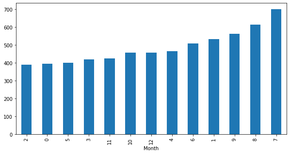

```python
Months_count = sad.groupby("Month").count().Date.sort_values()
Months_count[Months_count > 1].plot(kind="bar")
```

# 2. NUMBER OF ATTACKS AROUND THE WORLD

LOOK AT HOW THERE IS AN INCREASE AROUND 1958-1960's, WHY? INVESTIGATE THIS!

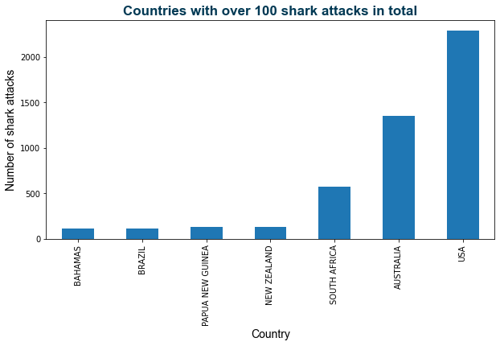

```python
country_count = sad.groupby("Country").count().Date.sort_values()
country_count[country_count > 100].plot(kind="bar")

plt.title('Countries with over 100 shark attacks in total', fontdict={'fontname': 'Arial', 'fontsize':17, 'fontweight':'bold'}, color='#013954')
plt.xlabel('Country', fontdict={'fontname': 'Arial', 'fontsize':14})
plt.ylabel('Number of shark attacks', fontdict={'fontname': 'Arial', 'fontsize':14})

plt.show()
```

[figure not shown]

```python
sad[(sad.Country == "USA") & (sad.Year < 2020) & (sad.Year > 1800)].groupby("Year").count().Date.plot()
sad[(sad.Country == "AUSTRALIA") & (sad.Year < 2020) & (sad.Year > 1800)].groupby("Year").count().Date.plot()
sad[(sad.Country == "SOUTH AFRICA") & (sad.Year < 1980) & (sad.Year > 1950)].groupby("Year").count().Date.plot()

plt.title('Number of Shark attacks in USA, Australia & South Africa between 1800-2020', fontdict={'fontname': 'Arial', 'fontsize':17, 'fontweight':'bold'}, color='#013954')
plt.xlabel('Year', fontdict={'fontname': 'Arial', 'fontsize':14})
plt.ylabel('Number of shark attacks', fontdict={'fontname': 'Arial', 'fontsize':14})

plt.tight_layout()
plt.show()
```

[output not shown]

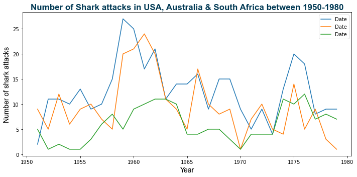

```python
usa= sad[(sad.Country == "USA") & (sad.Year < 1980) & (sad.Year > 1950)].groupby("Year").count().Date.plot()
aus= sad[(sad.Country == "AUSTRALIA") & (sad.Year < 1980) & (sad.Year > 1950)].groupby("Year").count().Date.plot()
sa= sad[(sad.Country == "SOUTH AFRICA") & (sad.Year < 1980) & (sad.Year > 1950)].groupby("Year").count().Date.plot()

plt.title('Number of Shark attacks in USA, Australia & South Africa between 1950-1980', fontdict={'fontname': 'Arial', 'fontsize':17, 'fontweight':'bold'}, color='#013954')
plt.xlabel('Year', fontdict={'fontname': 'Arial', 'fontsize':14})
plt.ylabel('Number of shark attacks', fontdict={'fontname': 'Arial', 'fontsize':14})

plt.tight_layout()

plt.legend()
plt.show()
```

https://www.floridamuseum.ufl.edu/science/how-a-century-of-fear-turned-deadly-for-sharks/

LOOK AT THE RISE IN ACTIVITIES SINCE 1960's and see if this correlates with the date and stament said before!

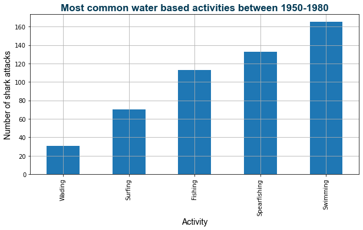

```python
country_count = sad[(sad.Year < 1980) & (sad.Year > 1950)].groupby("Activity").count().Date.sort_values()
country_count[country_count > 30].plot(kind="bar")

plt.title('Most common water based activities between 1950-1980', fontdict={'fontname': 'Arial', 'fontsize':17, 'fontweight':'bold'}, color='#013954')
plt.xlabel('Activity', fontdict={'fontname': 'Arial', 'fontsize':14})
plt.ylabel('Number of shark attacks', fontdict={'fontname': 'Arial', 'fontsize':14})

plt.grid()
plt.show()
```

[figure not shown]

```python
country_count = sad[(sad.Year < 2020) & (sad.Year > 1990)].groupby("Activity").count().Date.sort_values()
country_count[country_count > 30].plot(kind="bar")

plt.title('Most common water based activities between 1950-1980', fontdict={'fontname': 'Arial', 'fontsize':17, 'fontweight':'bold'}, color='#013954')
plt.xlabel('Activity', fontdict={'fontname': 'Arial', 'fontsize':14})
plt.ylabel('Number of shark attacks', fontdict={'fontname': 'Arial', 'fontsize':14})

plt.show()
```

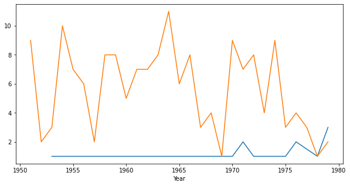

```python
sad[(sad.Activity == "Scuba diving") & (sad.Year < 1980) & (sad.Year > 1950)].groupby("Year").count().Date.plot()
sad[(sad.Activity == "Swimming") & (sad.Year < 1980) & (sad.Year > 1950)].groupby("Year").count().Date.plot()
```

ALL CODE BELOW IS RUBBISH JUST TESTING DIFFERENT THINGS!

[figure not shown]

```python
bins = [2010, 2011, 2012, 2013, 2014, 2015, 2016, 2017, 2018, 2019, 2020]

plt.hist(sad["Year"], bins=bins, color='#013954')
plt.xticks(bins)

plt.ylabel('Number of shark attacks', fontdict={'fontname': 'Arial', 'fontsize':14})
plt.xlabel('Year', fontdict={'fontname': 'Arial', 'fontsize':14})
plt.title('Number of shark attacks between 2000-2020', fontdict={'fontname': 'Arial', 'fontsize':17, 'fontweight':'bold'}, color='#013954')
plt.grid(True,color='#bfd2d9')

plt.show()
```

- During which months specificly were people being attacked? Summer, winter, etc... / colour code these colours accorddingly so we can clearly differenciate the seasons / Add a lengend/key

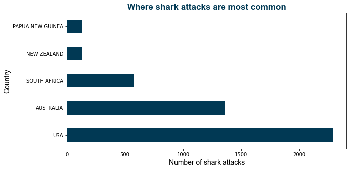

```python
Season_attacks = sad['Country'].value_counts()[:5]
Season_attacks.plot(kind='barh', color='#013954')

plt.title('Where shark attacks are most common', fontdict={'fontname': 'Arial', 'fontsize':17, 'fontweight':'bold'}, color='#013954')
plt.xlabel('Number of shark attacks', fontdict={'fontname': 'Arial', 'fontsize':14})
plt.ylabel('Country', fontdict={'fontname': 'Arial', 'fontsize':14})

plt.show()
```

- Where are people being attack the most worldwide? / Top 10 list with numbers
- Looking more in Australia which states have the most attacked

HOW TO MAKE MONTH SPECIFIC DATA

- NSW look at a map and findout where /which locations are being attcked

HOW DO I NARROW THIS DOWN TO AUSTRALIAN STATE????

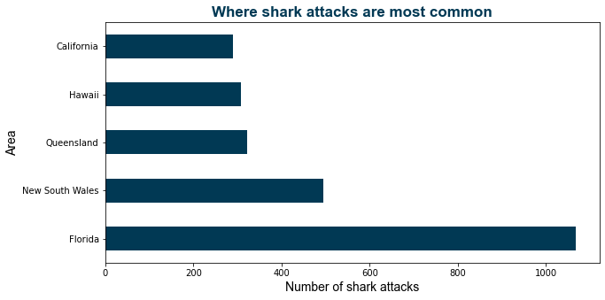

```python
Season_attacks = sad['Area'].value_counts()[:5]
Season_attacks.plot(kind='barh', color='#013954')

plt.title('Where shark attacks are most common', fontdict={'fontname': 'Arial', 'fontsize':17, 'fontweight':'bold'}, color='#013954')
plt.xlabel('Number of shark attacks', fontdict={'fontname': 'Arial', 'fontsize':14})
plt.ylabel('Area', fontdict={'fontname': 'Arial', 'fontsize':14})

plt.show()
```

[figure not shown]

```python
Season_attacks = sad['Type'].value_counts()[:5]
Season_attacks.plot(kind='barh', color='#540101')

plt.title('Cause of shark attacks', fontdict={'fontname': 'Arial', 'fontsize':17, 'fontweight':'bold'}, color='#540101')
plt.xlabel('Cause', fontdict={'fontname': 'Arial', 'fontsize':14})
plt.ylabel('Amount of attacks', fontdict={'fontname': 'Arial', 'fontsize':14})

plt.show()
```